# R Notebook

### Quiz 2

```r
BiocManager::install("sva")
```

```r
library(SummarizedExperiment)
library(Biobase)
library(GenomicRanges)
library(broom)
library(limma)
library(dplyr)
```

### PCA - Question 1

How to calculate the percent of variance explained?

- https://stats.stackexchange.com/questions/22569/pca-and-proportion-of-variance-explained
- http://jtleek.com/genstats/inst/doc/02_03_dimension-reduction.html#look-at-the-percent-variance-explained
- http://genomicsclass.github.io/book/pages/svd.html

```r
con =url("http://bowtie-bio.sourceforge.net/recount/ExpressionSets/montpick_eset.RData")
load(file=con)
close(con)
mp = montpick.eset
pdata=pData(mp)
edata=as.data.frame(exprs(mp))
fdata = fData(mp)
```

```r
edata2 = log2(edata + 1)
edata3 = edata2 - rowMeans(edata2) #worth checking if this is correct.
svd1 = svd(edata) #need to repeat for each of edata1,2,3
names(svd1)
```

```
[1] "d" "u" "v"
```

Just for fun, plot the relative size of singular values.

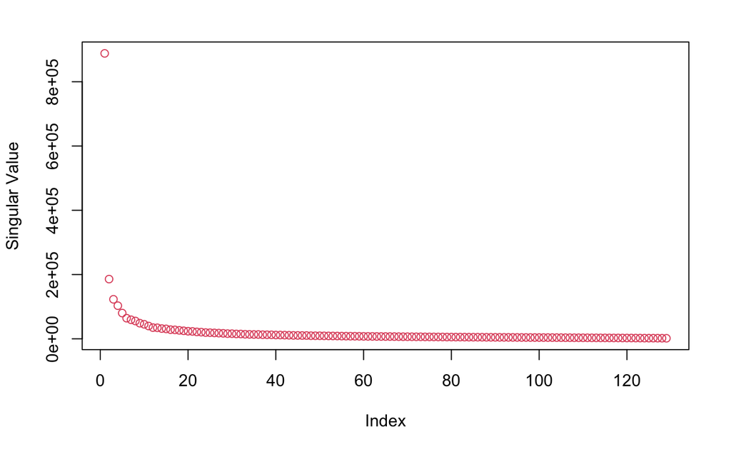

```r
plot(svd1$d, ylab="Singular Value", col=2)
```

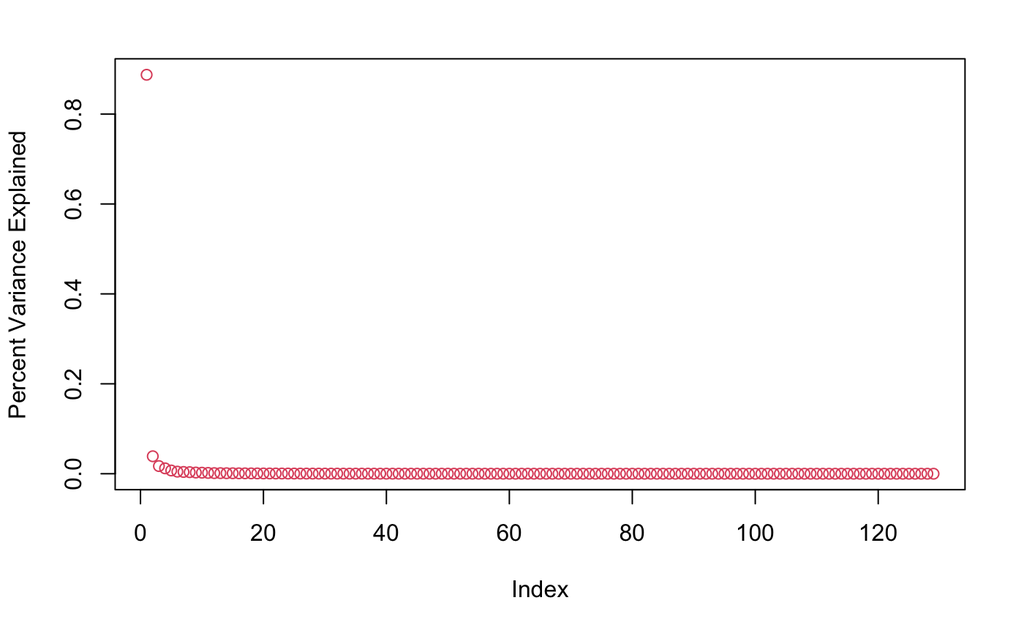

```r
plot(svd1$d^2/sum(svd1$d^2),ylab="Percent Variance Explained",col=2)
```

```r
svd2 = svd(edata2)
svd3 = svd(edata3)
```

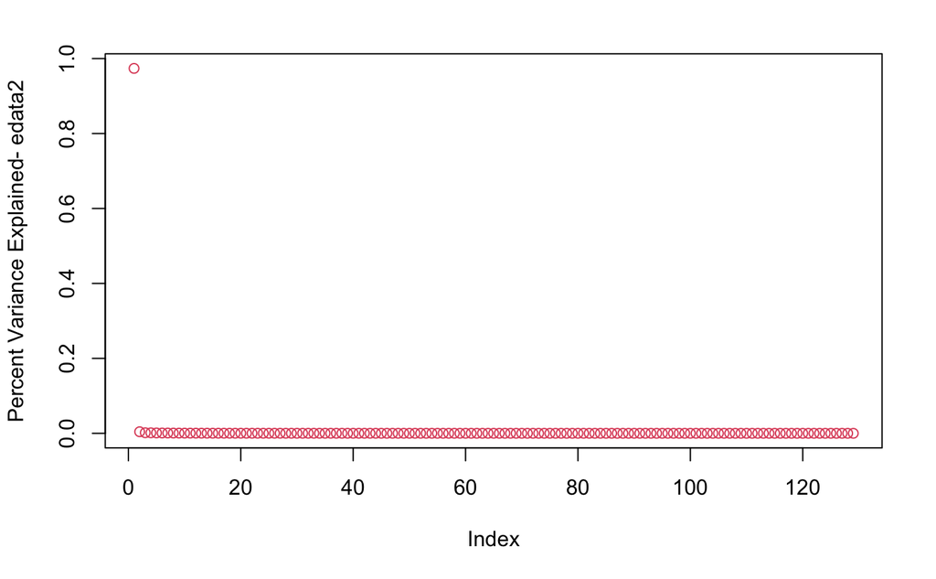

```r
plot(svd2$d^2/sum(svd2$d^2),ylab="Percent Variance Explained- edata2",col=2)
```

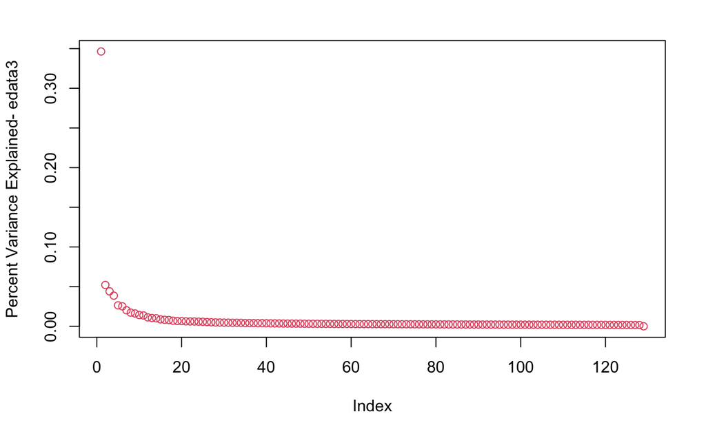

```r
plot(svd3$d^2/sum(svd3$d^2),ylab="Percent Variance Explained- edata3",col=2)
```

One thing to remember, SVD can flip signs.

#### K-means clustering + SVD correlation - Question 2

```r
#log2 transform + rowmeans
edataQ2 = log2(edata + 1)
edataQ2 = edataQ2 - rowMeans(edataQ2)
```

```r
set.seed(333)
kmQ2 = kmeans(t(edataQ2), 2)
svdQ2 = svd(edataQ2)
```

```r
cor(svdQ2$v[,1], kmQ2$cluster)
```

```
[1] -0.8678247
```

### Question 3 Linear models

Fit a linear model related the first gene’s counts to the number of technical replicates. Treat the number of technical replicates as a factor.

See

- http://jtleek.com/genstats/inst/doc/02_13_batch-effects.html
- http://jtleek.com/genstats/inst/doc/02_08_poverty-example.html
- http://jtleek.com/genstats/inst/doc/02_11_many-regressions.html
- http://jtleek.com/genstats/inst/doc/02_06_galton-example.html
- https://genomicsclass.github.io/book/pages/adjusting_with_linear_models.html
- https://genomicsclass.github.io/book/pages/eda_with_pca.html
- https://genomicsclass.github.io/book/pages/expressing_design_formula.html

```r
con =url("http://bowtie-bio.sourceforge.net/recount/ExpressionSets/bodymap_eset.RData")
load(file=con)
close(con)
bm = bodymap.eset
edata = exprs(bm)
pdata_bm=pData(bm)
```

```r
#gene1 = as.matrix(edata[1,])
#reps = as.matrix(as.factor(pdata$num.tech.reps))
#lm <- lm.fit(gene1 ~ reps)

mod = model.matrix(~ as.factor(num.tech.reps), data=pdata_bm)
fit = lm.fit(mod, t(edata))
```

Plot the data for this gene versus the covariate. Can you think of why this model might not fit well?

- The data are right skewed.

Right skewed distributions would have a long tail on the RHS. They would also show Mode <= Median <= Mean. There is so little data here I have mixed feelings as to whether I’d categorize this as a true right skewed distribution. Also, we’re just talking about a histogram of counts for `num.tech.reps` so I’m not sure if that qualifies for “the data”.

- There is only one data point with a value of 6 so it is likely that the estimated value for that number of technical replicates is highly variable.

Certainly the value for 6 rechnical replicates would be more variable. I’m not sure that explains why the fit is off. So far, I’d pick this answer.

- There may be different numbers of counts for different numbers of technical replicates.

What does “numbers of counts” mean? I would assume absolute count values are divided by the numbder of technical replicates. I’m not sure what this answer is stating.

- The difference between 2 and 5 technical replicates is not the same as the difference between 5 and 6 technical replicates.

There is certainly a gap in data between 2 and 5. 5 and 6 are much closer Does that explain why the fit might be off? No.

```r
#3 rows by 52k cols. Look in the first column for data about the first gene
dim(fit$coefficients)
```

```
[1]     3 52580
```

```r
#why three coefficients?
fit$coefficients[,1]
```

```
              (Intercept) as.factor(num.tech.reps)5 as.factor(num.tech.reps)6
                 784.1875                 5004.8125                 3829.8125
```

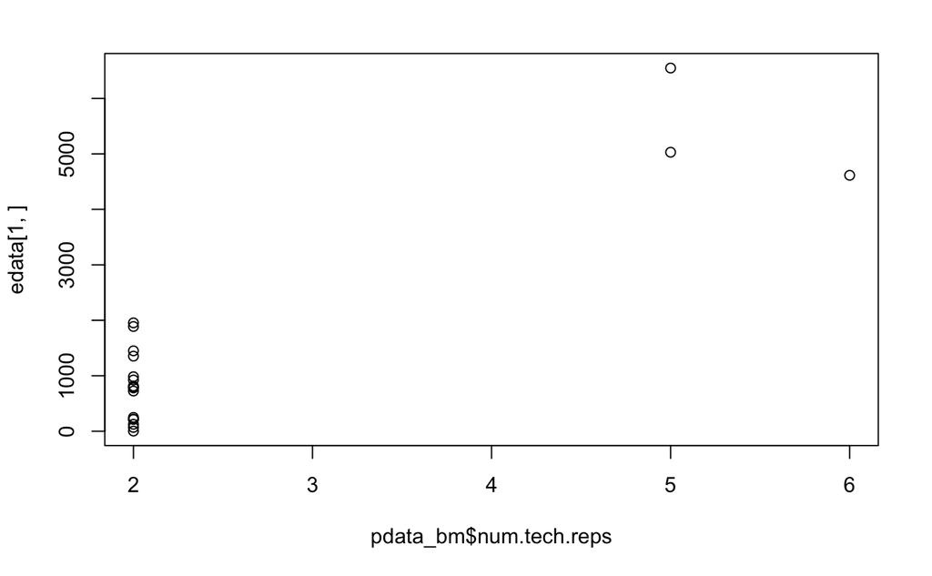

```r
#what should I plot? Historgram or linear model? In video lecture about correcting for batch effects a histogram is plotted first.

# histogram would likely be gene expression level on y axis and num technical replicates n x-axis.  This would be the same setup for a linear model.
plot(pdata_bm$num.tech.reps, edata[1,])
```

Just for fun, let’s plot this with ggplot

```r
library(ggplot2)
```

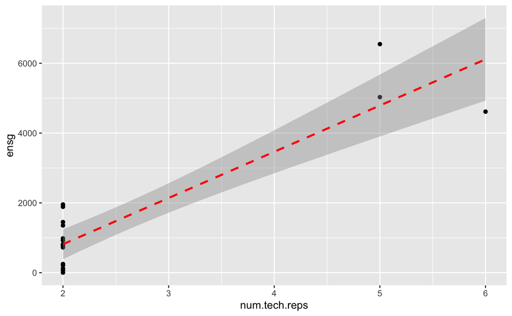

```r
df <- data.frame(ensg = edata[1,], num.tech.reps = pdata_bm$num.tech.reps)
ggplot(data=df, aes(y=ensg, x = num.tech.reps)) + geom_point() + geom_smooth(method="lm", color="red", linetype=2, formula="y~x")
```

4. Fit a linear model relating the first gene’s counts to the age of the person and the sex of the samples. What is the value and interpretation of the coefficient for age?

Let’s try fitting all genes just for fun.

```r
options(na.action='na.pass')
m4  <- model.matrix(~age + as.factor(gender), data=pdata_bm)
#ft4 <- lm.fit(m4, t(edata), na.action='na.pass')
lm4a <- lm(t(edata) ~ age + gender, data=pdata_bm, na.action = na.omit)
```

Now can we fit just the first gene?

```r
gene1_4 <- edata[1,]
lm4 <- lm(gene1_4 ~ age + gender, data=pdata_bm, na.action = na.omit)
tidy(lm4)
```

| term | estimate | std.error | statistic | p.value |
| --- | --- | --- | --- | --- |
| (Intercept) | 2331.5814 | 438.181127 | 5.3210448 | 0.000138739 |
| age | -23.9133 | 6.488058 | -3.6857414 | 0.002743642 |
| genderM | -207.2565 | 236.430512 | -0.8766066 | 0.396610372 |

Question 5

Load the Montgomery and Pickrell

```r
# This should already have been loaded by work for other questions.

#con =url("http://bowtie-bio.sourceforge.net/recount/ExpressionSets/montpick_eset.RData")
#load(file=con)
#close(con)
mp = montpick.eset
pdata = pData(mp)
edata = as.data.frame(exprs(mp))
fdata = fData(mp)
```

Perform the `log2(data + 1)` transform. Then fit a regression model to each sample using population as the outcome. Do this using the **lm.fit** function (hint: don’t forget the intercept). What is the dimension of the residual matrix, the effects matrix and the coefficients matrix?

```r
edata_q5 = log2(edata + 1)
mm = model.matrix(~population, pdata)
fit = lm.fit(mm, t(edata_q5))
```

Question 6.

Given the data model in question 5, what is the effects matrix?

Never heard of this before. Some references

- https://docs.tibco.com/pub/enterprise-runtime-for-R/4.1.0/doc/html/Language_Reference/stats/lm.fit.html
- https://astrostatistics.psu.edu/su07/R/html/stats/html/effects.html
- https://genomicsclass.github.io/book/pages/qr_and_regression.html
- https://stats.idre.ucla.edu/other/mult-pkg/introduction-to-linear-mixed-models/

Related to QR decomposition. Possibly related to linear mixture models.

Best guess answer:

“The model coefficients for all samples for each gene, with the values for each gene stored in the columns of the matrix.”

Second guess

“The estimated fitted values for all samples for each gene, with the values for each gene stored in the columns of the matrix.”

Question 7

Fit many regression models to the expression data where **age** is the outcome variable using the **lmFit** function from the **limma** package (hint: you may have to subset the expression data to the samples without missing values of age to get the model to fit). What is the coefficient for age for the 1,000th gene? Make a plot of the data and fitted values for this gene. Does the model fit well?

References - Limma / LmFit

- http://genomicsclass.github.io/book/pages/bioc1_geneset_1.html
- http://jtleek.com/genstats/inst/doc/02_11_many-regressions.html
- http://jtleek.com/genstats/inst/doc/03_09_Calculating_statistics.html

```r
bm = bodymap.eset
edata = exprs(bm)
pdata_bm=pData(bm)
```

```r
#this gets  rid of the rows with age == NA
#pdb <- pdata_bm %>%
#  filter(!is.na(age))

#which rows or cols to drop
bad_samples = which(is.na(pdata_bm$age))

pdataQ7 <- pdata_bm[-1*bad_samples,]
edataQ7 <- edata[,-1*bad_samples]

modQ7 <- model.matrix(~ age, pdataQ7) #note: age is a predictor variable not an outcome variable.
fitQ7 <- lmFit(edataQ7, modQ7)
```

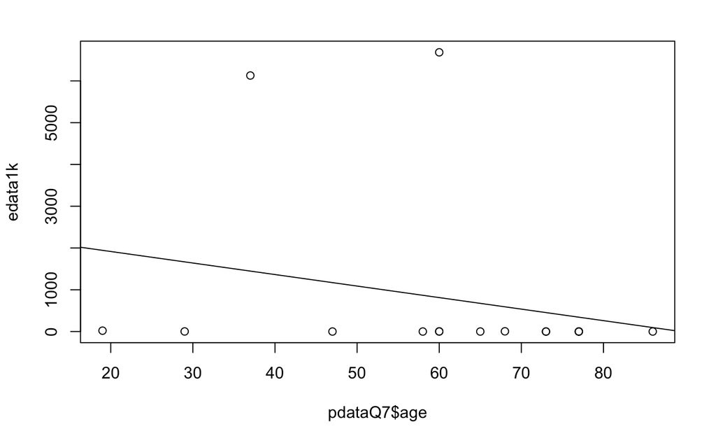

```r
edata1k = edataQ7[1000,]


plot(pdataQ7$age, edata1k)
abline(okc['(Intercept)'], okc['age'])
```

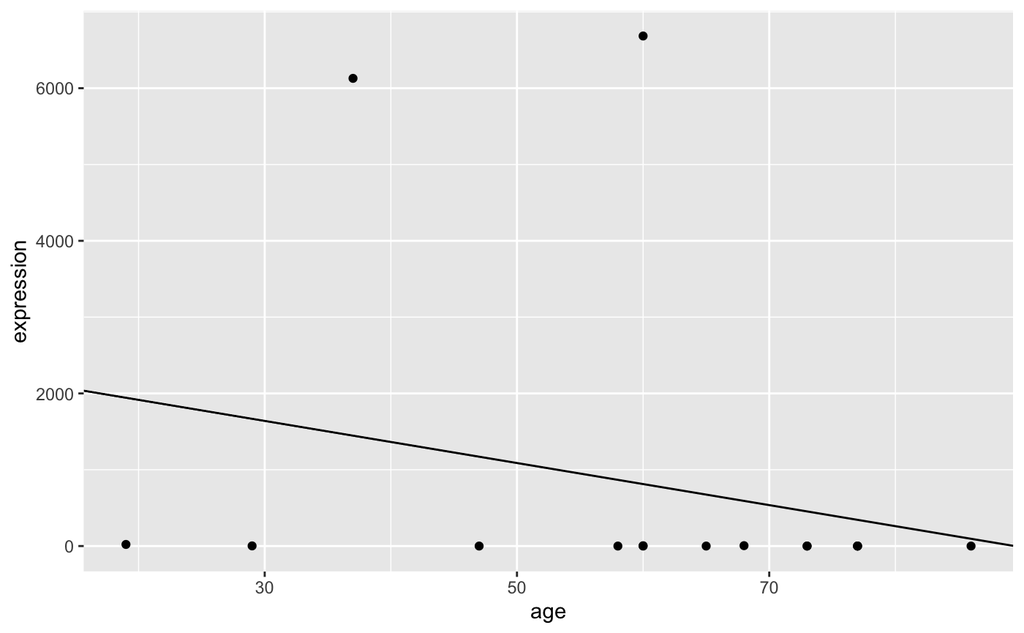

```r
#construct dataframe from pdataQ7$age and edata1k.
dfQ7 <- data.frame(expression = edata1k, age = pdataQ7$age)

ggplot(dfQ7, aes(x=age, y=expression)) +
  geom_point() +
  geom_abline(slope=okc['age'] , intercept=okc['(Intercept)'] )
```

```r
bm = bodymap.eset
edataQ8 = exprs(bm)
pdataQ8=pData(bm)
```

Fit many regression models to the expression data where **age** is the outcome variable and **tissue.type** is an adjustment variable using the **lmFit** function from the **limma** package (hint: you may have to subset the expression data to the samples without missing values of age to get the model to fit). What is wrong with this model?

```r
bs8 = which(is.na(pdata_bm$age))

pdataQ8 <- pdataQ8[-1*bs8,]
edataQ8 <- edataQ8[,-1*bs8]

dim(edataQ8)
```

```
[1] 52580    13
```

```r
dim(pdataQ8)
```

```
[1] 13  6
```

```r
modq8 <- model.matrix(age ~ tissue.type, pdataQ8)
fitq8 <- lmFit(edataQ8, modq8)
```

```
Coefficients not estimable: tissue.typemixture tissue.typeovary tissue.typeprostate tissue.typeskeletal_muscle
```

```
Partial NA coefficients for 52580 probe(s)
```

Question 9.

```r
#assumes you loaded the MP dataset
mp = montpick.eset
pdata=pData(mp)

library(dplyr)
glimpse(pdata)

pdata %>%
  filter(study =="Pickrell", population == "CEU")
```

[output not shown]

Question 10.

Load the Bodymap data with the following command

Set the seed using the command `set.seed(33353)` then estimate a single surrogate variable using the `sva` function after `log2(data + 1)` transforming the expression data, removing rows with rowMeans less than 1, and treating age as the outcome (hint: you may have to subset the expression data to the samples without missing values of age to get the model to fit).

- What is the correlation between the estimated surrogate for batch and age?
- Is the surrogate more highly correlated with `race` or `gender`?

### Resources

- http://jtleek.com/genstats/inst/doc/02_13_batch-effects.html

```r
library(sva)
bm = bodymap.eset
edata = exprs(bm)
pdata_bm=pData(bm)
set.seed(33353)
```

```r
#remove missing age variables
has_age  = which(!is.na(pdata_bm$age))
pdataq10 = pdata_bm[has_age,]

edata_lg2 = log2(edata + 1)
edataq10 = edata_lg2[which(rowMeans(edata_lg2) >=  1), has_age ]

#does this really treat age as the outcome?
mAge <- model.matrix(~age, data=pdataq10)
m0   <- model.matrix(~1, data=pdataq10)
set.seed(33353)
sva10 = sva(edataq10, mAge, m0, n.sv=1)
```

```
Number of significant surrogate variables is:  1
Iteration (out of 5 ):1  2  3  4  5
```

I believe you can use the R^2 value for correlation b/c you have only one variable. This might be wrong.

```r
summary(lm(sva10$sv ~ pdataq10$age))
```

```
Call:
lm(formula = sva10$sv ~ pdataq10$age)

Residuals:
     Min       1Q   Median       3Q      Max
-0.57179 -0.06658  0.07130  0.13396  0.34456

Coefficients:
              Estimate Std. Error t value Pr(>|t|)
(Intercept)   0.191358   0.225006   0.850    0.409
pdataq10$age -0.003169   0.003568  -0.888    0.389

Residual standard error: 0.26 on 14 degrees of freedom
Multiple R-squared:  0.05336,   Adjusted R-squared:  -0.01426
F-statistic: 0.7892 on 1 and 14 DF,  p-value: 0.3894
```

```r
cor(sva10$sv[,1], pdataq10$age)
```

```
[1] -0.2309982
```

Not getting any answers that are options in the multiple choice.